First, let us load the data and necessary packages:

```r
load("ames_train.Rdata")
library(MASS)
library(dplyr)
library(ggplot2)
options(warn=-1)
```

# 1

Make a labeled histogram (with 30 bins) of the ages of the houses in the data set, and describe the distribution:

In this case we will define the age of the house as the current year minus the Year.Built value and stored in house_age.

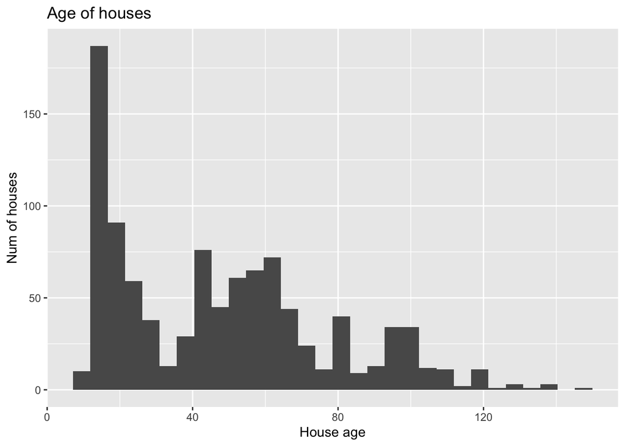

```r
ames_train["house_age"] <- as.numeric(substr(Sys.Date(), 0, 4)) - ames_train$Year.Built
ggplot(data = ames_train, aes(x = house_age)) + geom_histogram(bins = 30) + labs(title = "Age of houses", y="Num of houses", x="House age")
```

# 2

The mantra in real estate is “Location, Location, Location!” Make a graphical display that relates a home price to its neighborhood in Ames, Iowa. Which summary statistics are most appropriate to use for determining the most expensive, least expensive, and most heterogeneous (having the most variation in housing price) neighborhoods? Report which neighborhoods these are based on the summary statistics of your choice. Report the value of your chosen summary statistics for these neighborhoods.

First lets group the Neighborhoods and get the summary stats for each one:

```r
summary_stats = ames_train %>% group_by(Neighborhood) %>% summarize(mean = mean(price), median = median(price), max = max(price), min = min(price), std_dev = sd(price),n = n(), iqr = IQR(price))
print(summary_stats, n=30)
```

```
## # A tibble: 27 x 8
##    Neighborhood    mean  median    max    min std_dev     n     iqr
##    <fct>          <dbl>   <dbl>  <int>  <int>   <dbl> <int>   <dbl>
##  1 Blmngtn      198635. 191000  246990 172500  26455.    11  22888.
##  2 Blueste      125800  123900  137000 116500  10381.     3  10250
##  3 BrDale        98930   98750  125500  83000  13338.    10  16725
##  4 BrkSide      122473. 124000  207000  39300  37310.    41  42000
##  5 ClearCr      193154. 185000  277000 107500  48069.    13  76000
##  6 CollgCr      196951. 195800  475000 110000  52786.    85  58836
##  7 Crawfor      204197. 205000  392500  96500  71268.    29  80100
##  8 Edwards      136322. 127250  415000  61500  54852.    60  35750
##  9 Gilbert      193328. 183500  377500 133000  41190.    49  28000
## 10 Greens       198562. 212625  214000 155000  29063.     4  16438.
## 11 GrnHill      280000  280000  330000 230000  70711.     2  50000
## 12 IDOTRR        97621.  99500  150909  34900  31530.    35  48900
## 13 MeadowV       92947.  85750  129500  73000  18940.    16  20150
## 14 Mitchel      165014. 156500  285000  93500  39683.    44  32875
## 15 NAmes        141356. 139900  277500  76500  27268.   155  27050
## 16 NoRidge      295845. 290000  405000 235000  35889.    28  50312.
## 17 NPkVill      139275  142100  149900 123000  11958.     4  13025
## 18 NridgHt      333647. 336860  615000 173000 105089.    57 148800
## 19 NWAmes       194094. 185000  278000  82500  41341.    41  59100
## 20 OldTown      120226. 120000  265979  12789  36430.    71  29550
## 21 Sawyer       139313. 136000  219000  63900  21216.    61  20350
## 22 SawyerW      183101  182500  320000  67500  48354.    46  67000
## 23 Somerst      234596. 221650  468000 139000  65199.    74  72684.
## 24 StoneBr      339316. 340692. 591587 180000 123459.    20 151358
## 25 SWISU        130620. 134000  169000  80000  27376.    12  29250
## 26 Timber       265192. 232500  425000 175000  84030.    19 151200
## 27 Veenker      233650  205750  385000 150000  72545.    10  68125
```

The median price is our best bet for analysis when grouping by neighbourhood as it is less likely to be affected by outlier values. First link the median price per neighbourhood to the house price by joining the data to the summary_stats and re-ordering relative to Neighborhood and median price per neighbourhood.

```r
joined_data = ames_train %>% right_join(summary_stats) %>% mutate(Neighborhood=reorder(Neighborhood,median))
```

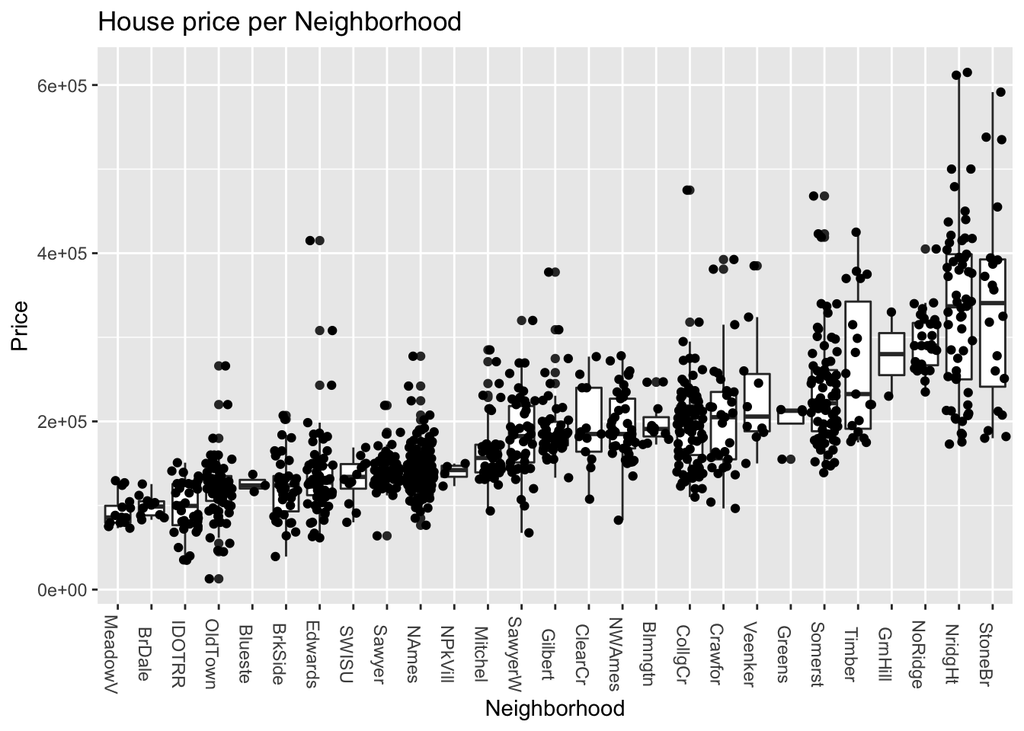

```r
ggplot(data=joined_data, aes(x=Neighborhood, y=price)) + geom_boxplot() + geom_jitter() + labs(title = "House price per Neighborhood", y="Price", x="Neighborhood") + theme(axis.text.x= element_text(angle=270))
```

Again using the median as it is less likely to be affected by outliers.

The most expensive neighbourhood by median price would be:

```r
tail(summary_stats[order(summary_stats$median),],1)
```

```
## # A tibble: 1 x 8
##   Neighborhood    mean  median    max    min std_dev     n    iqr
##   <fct>          <dbl>   <dbl>  <int>  <int>   <dbl> <int>  <dbl>
## 1 StoneBr      339316. 340692. 591587 180000 123459.    20 151358
```

The least expensive neighbourhood by median price would be:

```r
head(summary_stats[order(summary_stats$median),],1)
```

```
## # A tibble: 1 x 8
##   Neighborhood   mean median    max   min std_dev     n   iqr
##   <fct>         <dbl>  <dbl>  <int> <int>   <dbl> <int> <dbl>
## 1 MeadowV      92947.  85750 129500 73000  18940.    16 20150
```

The most heterogeneous neighbourhood by median price would be:

```r
tail(summary_stats[order(summary_stats$iqr),],1)
```

```
## # A tibble: 1 x 8
##   Neighborhood    mean  median    max    min std_dev     n    iqr
##   <fct>          <dbl>   <dbl>  <int>  <int>   <dbl> <int>  <dbl>
## 1 StoneBr      339316. 340692. 591587 180000 123459.    20 151358
```

The inter quartile range will give a good indication of variation.

# 3

Which variable has the largest number of missing values? Explain why it makes sense that there are so many missing values for this variable.

```r
print(ames_train %>%
  summarise_all(funs(sum(is.na(.)))), width=1100)
```

```
## # A tibble: 1 x 82
##     PID  area price MS.SubClass MS.Zoning Lot.Frontage Lot.Area Street Alley
##   <int> <int> <int>       <int>     <int>        <int>    <int>  <int> <int>
## 1     0     0     0           0         0          167        0      0   933
##   Lot.Shape Land.Contour Utilities Lot.Config Land.Slope Neighborhood
##       <int>        <int>     <int>      <int>      <int>        <int>
## 1         0            0         0          0          0            0
##   Condition.1 Condition.2 Bldg.Type House.Style Overall.Qual Overall.Cond
##         <int>       <int>     <int>       <int>        <int>        <int>
## 1           0           0         0           0            0            0
##   Year.Built Year.Remod.Add Roof.Style Roof.Matl Exterior.1st Exterior.2nd
##        <int>          <int>      <int>     <int>        <int>        <int>
## 1          0              0          0         0            0            0
##   Mas.Vnr.Type Mas.Vnr.Area Exter.Qual Exter.Cond Foundation Bsmt.Qual Bsmt.Cond
##          <int>        <int>      <int>      <int>      <int>     <int>     <int>
## 1            0            7          0          0          0        21        21
##   Bsmt.Exposure BsmtFin.Type.1 BsmtFin.SF.1 BsmtFin.Type.2 BsmtFin.SF.2
##           <int>          <int>        <int>          <int>        <int>
## 1            21             21            1             21            1
##   Bsmt.Unf.SF Total.Bsmt.SF Heating Heating.QC Central.Air Electrical
##         <int>         <int>   <int>      <int>       <int>      <int>
## 1           1             1       0          0           0          0
##   X1st.Flr.SF X2nd.Flr.SF Low.Qual.Fin.SF Bsmt.Full.Bath Bsmt.Half.Bath
##         <int>       <int>           <int>          <int>          <int>
## 1           0           0               0              1              1
##   Full.Bath Half.Bath Bedroom.AbvGr Kitchen.AbvGr Kitchen.Qual TotRms.AbvGrd
##       <int>     <int>         <int>         <int>        <int>         <int>
## 1         0         0             0             0            0             0
##   Functional Fireplaces Fireplace.Qu Garage.Type Garage.Yr.Blt Garage.Finish
##        <int>      <int>        <int>       <int>         <int>         <int>
## 1          0          0          491          46            48            46
##   Garage.Cars Garage.Area Garage.Qual Garage.Cond Paved.Drive Wood.Deck.SF
##         <int>       <int>       <int>       <int>       <int>        <int>
## 1           1           1          47          47           0            0
##   Open.Porch.SF Enclosed.Porch X3Ssn.Porch Screen.Porch Pool.Area Pool.QC Fence
##           <int>          <int>       <int>        <int>     <int>   <int> <int>
## 1             0              0           0            0         0     997   798
##   Misc.Feature Misc.Val Mo.Sold Yr.Sold Sale.Type Sale.Condition house_age
##          <int>    <int>   <int>   <int>     <int>          <int>     <int>
## 1          971        0       0       0         0              0         0
```

# 4

We want to predict the natural log of the home prices. Candidate explanatory variables are lot size in square feet (Lot.Area), slope of property (Land.Slope), original construction date (Year.Built), remodel date (Year.Remod.Add), and the number of bedrooms above grade (Bedroom.AbvGr). Pick a model selection or model averaging method covered in the Specialization, and describe how this method works. Then, use this method to find the best multiple regression model for predicting the natural log of the home prices.

I will be using the Backward Elimination. It works by defining a model with all candidate variables to obtain an initial adjusted R squared value, then they will be systematically removed to determine if their exclusion will yield a higher adjusted R squared value for the model. The model with the highest adjusted R squared will be the most predictive available.

The initial full model with all candidate variables:

```r
sub_set <- ames_train %>% select(price, Lot.Area, Land.Slope, Year.Built, Year.Remod.Add, Bedroom.AbvGr)
initial_model <- lm(log(price) ~ Lot.Area + Land.Slope + Year.Built + Year.Remod.Add + Bedroom.AbvGr, data = sub_set)
summary(initial_model)$adj.r.squared
```

```
## [1] 0.5598345
```

Now each of the explanatory variables will be removed (Lot.Area, Land.Slope, Year.Built, Year.Remod.Add, Bedroom.AbvGr)

```r
# Remove Lot.Area
summary(lm(log(price) ~ Land.Slope + Year.Built + Year.Remod.Add + Bedroom.AbvGr, data = sub_set))$adj.r.squared
```

```
## [1] 0.522009
```

```r
# Remove Land.Slope
summary(lm(log(price) ~ Lot.Area + Year.Built + Year.Remod.Add + Bedroom.AbvGr, data = sub_set))$adj.r.squared
```

```
## [1] 0.5526062
```

```r
# Remove Year.Built
summary(lm(log(price) ~ Lot.Area + Land.Slope + Year.Remod.Add + Bedroom.AbvGr, data = sub_set))$adj.r.squared
```

```
## [1] 0.4473663
```

```r
# Remove Year.Remod.Add
summary(lm(log(price) ~ Lot.Area + Land.Slope + Year.Built + Bedroom.AbvGr, data = sub_set))$adj.r.squared
```

```
## [1] 0.4922384
```

```r
# Remove Bedroom.AbvGr
summary(lm(log(price) ~ Lot.Area + Land.Slope + Year.Built + Year.Remod.Add, data = sub_set))$adj.r.squared
```

```
## [1] 0.5314859
```

The removal of a candidate explanatory variable will not lead to a higher adjusted R squared value over the initial model, so it will remain unchanged. This was determined by following the Backward Elimination method (adjusted R squared). So the final model is:

```r
summary(initial_model)
```

```
##
## Call:
## lm(formula = log(price) ~ Lot.Area + Land.Slope + Year.Built +
##     Year.Remod.Add + Bedroom.AbvGr, data = sub_set)
##
## Residuals:
##     Min      1Q  Median      3Q     Max
## -2.0878 -0.1651 -0.0211  0.1657  0.9945
##
## Coefficients:
##                  Estimate Std. Error t value Pr(>|t|)
## (Intercept)    -1.371e+01  8.574e-01 -15.996  < 2e-16 ***
## Lot.Area        1.028e-05  1.106e-06   9.296  < 2e-16 ***
## Land.SlopeMod   1.384e-01  4.991e-02   2.773  0.00565 **
## Land.SlopeSev  -4.567e-01  1.514e-01  -3.016  0.00263 **
## Year.Built      6.049e-03  3.788e-04  15.968  < 2e-16 ***
## Year.Remod.Add  6.778e-03  5.468e-04  12.395  < 2e-16 ***
## Bedroom.AbvGr   8.686e-02  1.077e-02   8.063 2.12e-15 ***
## ---
## Signif. codes:  0 '***' 0.001 '**' 0.01 '*' 0.05 '.' 0.1 ' ' 1
##
## Residual standard error: 0.279 on 993 degrees of freedom
## Multiple R-squared:  0.5625, Adjusted R-squared:  0.5598
## F-statistic: 212.8 on 6 and 993 DF,  p-value: < 2.2e-16
```

Checking the residuals for this model:

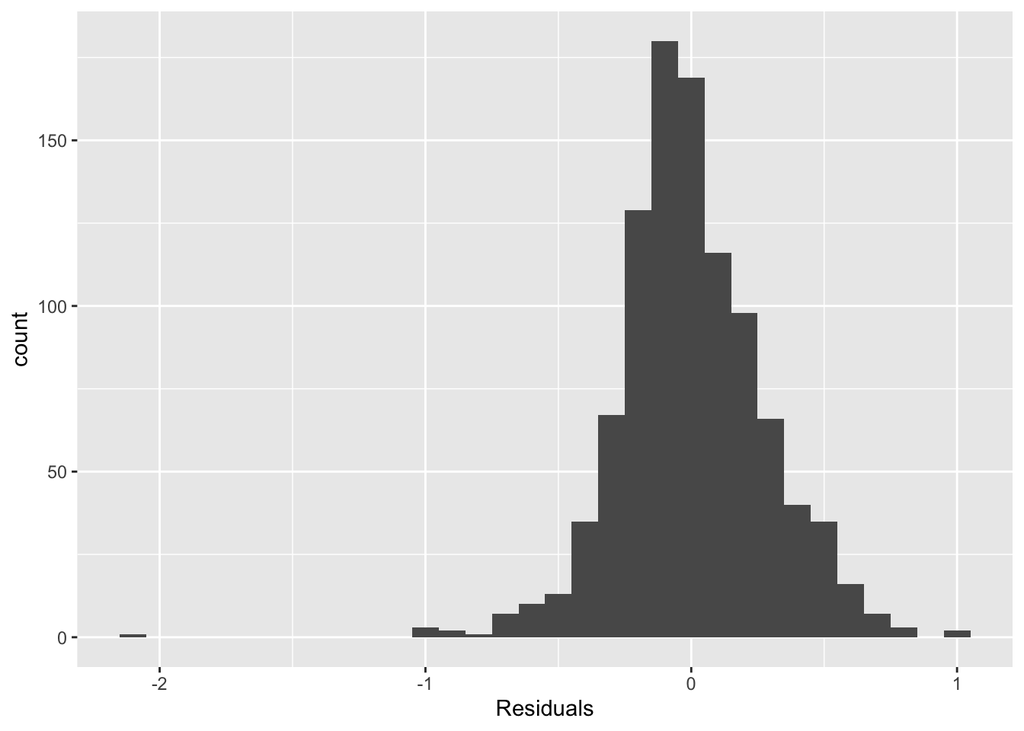

```r
ggplot(data = initial_model, aes(x = .resid)) + geom_histogram(binwidth = 0.1) +
  xlab("Residuals")
```

from this we can see that the residuals are normal about 0. There appears to be an outlier towards the -2 mark.

# 5

Which home has the largest squared residual in the previous analysis (Question 4)? Looking at all the variables in the data set, can you explain why this home stands out from the rest (what factors contribute to the high squared residual and why are those factors relevant)?

The outlier has been commented on in the previous question, looking at another plot of it:

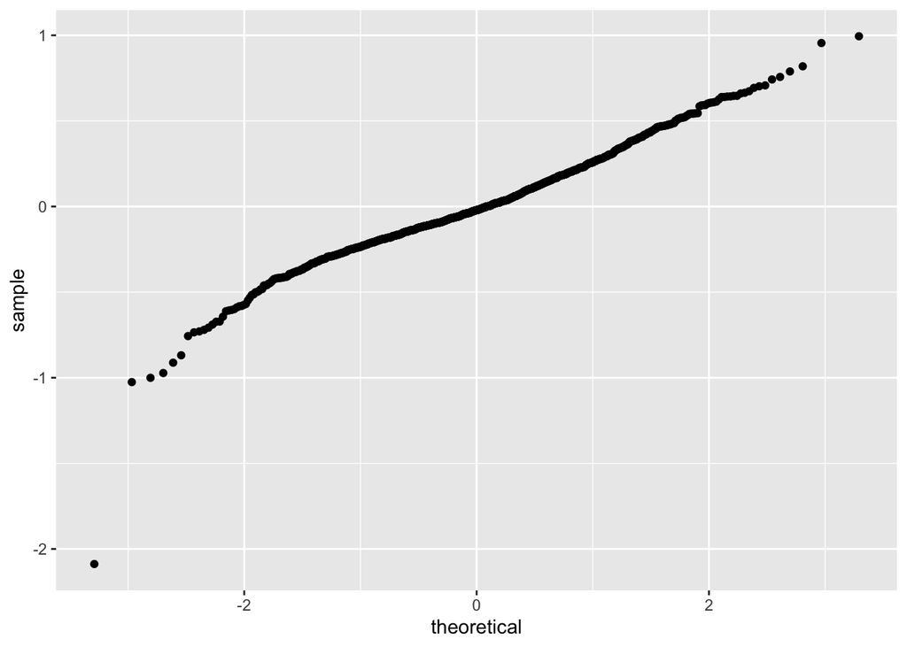

```r
ggplot(data = initial_model, aes(sample = .resid)) +
  stat_qq()
```

The row of outlier is number:

```r
which.min(initial_model$residuals)
```

```
## 428
## 428
```

According to the ames_train data (row 428), this house has abnormal sale conditions, potentially an auction, maybe a private family sale or a trade and this maybe the reason for the outlier status.

# 6

Use the same model selection method you chose in Question 4 to again find the best multiple regression model to predict the natural log of home prices, but this time **replacing Lot.Area with log(Lot.Area)**. Do you arrive at a model including the same set of predictors?

The initial full model with all candidate variables using the Backward Elimination technique as discussed in Q4:

```r
initial_model2 <- lm(log(price) ~ log(Lot.Area) + Land.Slope + Year.Built + Year.Remod.Add + Bedroom.AbvGr, data = sub_set)
summary(initial_model2)$adj.r.squared
```

```
## [1] 0.6032018
```

Now each of the explanatory variables will be removed (log(Lot.Area), Land.Slope, Year.Built, Year.Remod.Add, Bedroom.AbvGr)

```r
# Remove log(Lot.Area)
summary(lm(log(price) ~ Land.Slope + Year.Built + Year.Remod.Add + Bedroom.AbvGr, data = sub_set))$adj.r.squared
```

```
## [1] 0.522009
```

```r
# Remove Land.Slope
summary(lm(log(price) ~ log(Lot.Area) + Year.Built + Year.Remod.Add + Bedroom.AbvGr, data = sub_set))$adj.r.squared
```

```
## [1] 0.6014831
```

```r
# Remove Year.Built
summary(lm(log(price) ~ log(Lot.Area) + Land.Slope + Year.Remod.Add + Bedroom.AbvGr, data = sub_set))$adj.r.squared
```

```
## [1] 0.4932282
```

```r
# Remove Year.Remod.Add
summary(lm(log(price) ~ log(Lot.Area) + Land.Slope + Year.Built + Bedroom.AbvGr, data = sub_set))$adj.r.squared
```

```
## [1] 0.5363921
```

```r
# Remove Bedroom.AbvGr
summary(lm(log(price) ~ log(Lot.Area) + Land.Slope + Year.Built + Year.Remod.Add, data = sub_set))$adj.r.squared
```

```
## [1] 0.5910888
```

The full model has a higher adjusted R squared value than the initial full model. No candidate explanatory variables are removed. Overall both models contain the same variables including Lot.Area/log(Lot.Area)

# 7

Do you think it is better to log transform Lot.Area, in terms of assumptions for linear regression? Make graphs of the predicted values of log home price versus the true values of log home price for the regression models selected for Lot.Area and log(Lot.Area). Referencing these two plots, provide a written support that includes a quantitative justification for your answer in the first part of question 7.

Firstly lets plot the residuals for model 1, the one with Lot.Area:

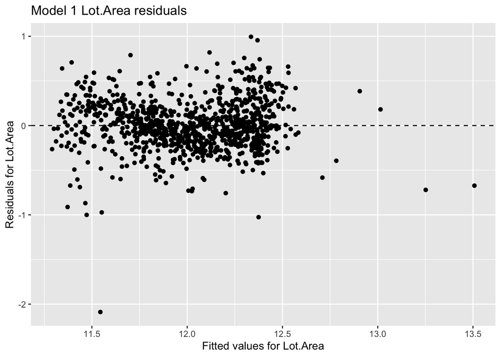

```r
ggplot(data = initial_model, aes(x = .fitted, y = .resid)) +
  geom_point() +
  geom_hline(yintercept = 0, linetype = "dashed") + labs(title = "Model 1 Lot.Area residuals", y="Residuals for Lot.Area", x="Fitted values for Lot.Area")
```

Residuals for model 2, the one with log(Lot.Area):

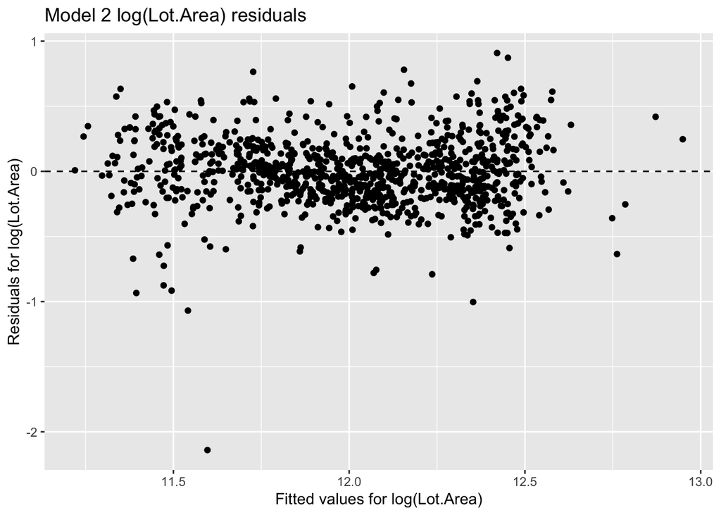

```r
ggplot(data = initial_model2, aes(x = .fitted, y = .resid)) +
  geom_point() +
  geom_hline(yintercept = 0, linetype = "dashed") + labs(title = "Model 2 log(Lot.Area) residuals", y="Residuals for log(Lot.Area)", x="Fitted values for log(Lot.Area)")
```

The above two graphs look fairly similar. Model 2 appears to be a bit more evenly spread, not as squashed as model 1. This is due to a few Fitted Lot.Area values extending past 13.0 in model 1. The logging appears to control this more in model 2.

Plotting the predictions of both models against the actual logged price:

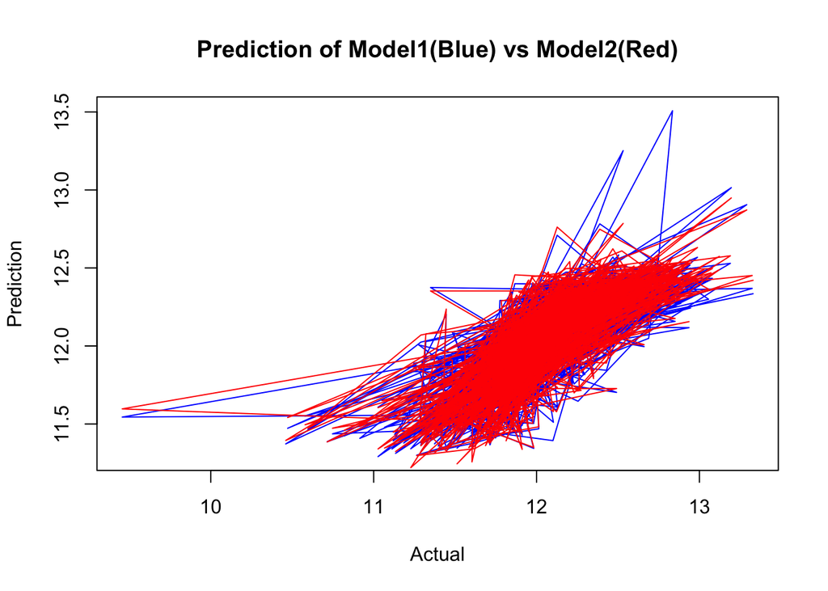

```r
actual = log(ames_train$price)
initial_model_pred = predict(initial_model)
initial_model2_pred = predict(initial_model2)

plot(actual,initial_model_pred,type="l",col="blue", main="Prediction of Model1(Blue) vs Model2(Red)", xlab="Actual", ylab="Prediction")
lines(actual,initial_model2_pred,col="red")
```

Model 1 is in blue and Model 2 is in red. From the graph the two models’ performance is very similar. But model 2 seems to be a bit tighter than model 1, this makes sense as the above linearity plots are a bit better for model 2 as well as it having a higher adjusted R squared value. But it must be noted that these differences are very minor and not necessarily significant.